# life history

Daniel Suh

1/28/2022

```r
library(tidyverse)
library(magrittr)
library(here)
```

```r
becker_han <- read_csv(here("data/Becker Han 2020 GEB_gpf & BRT data.csv"))
healy_axis <- read_csv(here("data/healy_axis_analysis.csv"))
healy_host <- read_csv(here("data/healy_host_par.csv"))
```

get parasite species richness from healy_host_par.csv

```r
healy_psr <- healy_host %>% dplyr::select(host, parasite) %>% group_by(host) %>% summarize(n=n())
```

join with life history data from healy_axis_analysis.csv first some string manipulation

```r
healy_axis %<>% mutate(host = gsub("_", " ", healy_axis$species))
healy_axis_psr <- left_join(healy_axis, healy_psr, by = "host")

#average over duplicates
healy_axis_psr_avg <- healy_axis_psr %>% group_by(species) %>% mutate_each(funs(mean), c(2:15,17,18,20,24)) %>% distinct()
healy_axis_psr_avg$mode_of_life <- factor(healy_axis_psr_avg$mode_of_life)
healy_axis_psr_avg$IUCN <- factor(healy_axis_psr_avg$IUCN)
healy_axis_psr_avg$met_type <- factor(healy_axis_psr_avg$met_type)

healy_axis_psr_avg %<>% dplyr::select(-c(taxa_name,animal,host))
```

mock pca - dont trust this. just checking out workflow

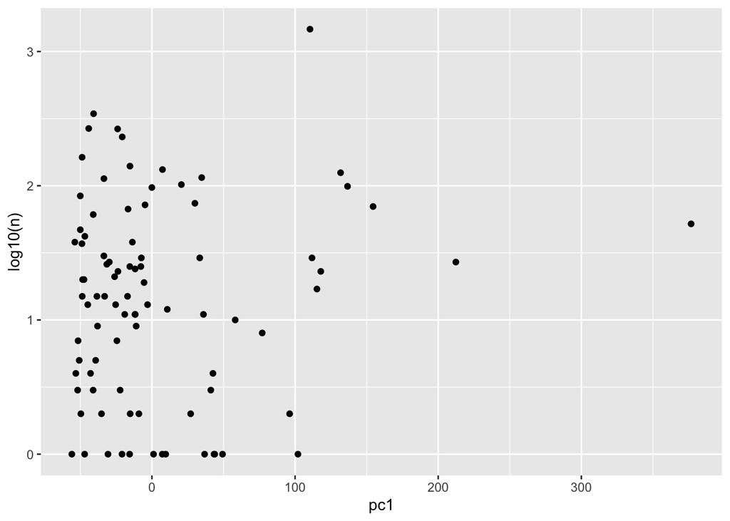

```r
healy_pca <- healy_axis_psr_avg %>% dplyr::select(-c(mode_of_life,IUCN,met_type,repo_output,met_rate,n,mass_g,mean_repo_rate)) %>% column_to_rownames(.,var="species")
healy_pca_results <- prcomp(healy_pca)
pc1_scores <- enframe(healy_pca_results$x[,1], name = "species", value = "pc1")
tmp <- healy_axis_psr_avg %>% dplyr::select(species, mean_life_expect, n)
pc1_scores %<>% left_join(.,tmp, by = "species")
pc1_scores %>% ggplot(.,aes(x=pc1,y=log10(n))) + geom_point()
```

## TREES

Let’s look at some trees We can start with just GMPD and Pantheria data

```r
gmpd <- read_csv(here("data/GMPD_main.csv"))
panth1 <- read_tsv(here("data/pantheria/ECOL_90_184/PanTHERIA_1-0_WR05_Aug2008.txt"))
panth2 <- read_tsv(here("data/pantheria/ECOL_90_184/PanTHERIA_1-0_WR93_Aug2008.txt"))
```

Not totally sure what is difference between panth1 and panth2 but panth1 has more entries and has more records for every order when broken down by order so we’ll use that for now

Not sure what some of the final variables for panth really mean so we’ll just exclude them for now

```r
panth1 %<>% dplyr::select(MSW05_Order:`5-7_WeaningBodyMass_g_EXT`)
```

```r
gmpd_PSR <- gmpd %>% dplyr::select(HostCorrectedName,ParasiteCorrectedName) %>% distinct() %>%
  group_by(HostCorrectedName) %>% summarize(psr=n())
panth1 %<>% mutate(HostCorrectedName = MSW05_Binomial)
gmpd_panth <- gmpd_PSR %>% inner_join(panth1, by="HostCorrectedName")
```

Let’s deal with all the -999 and the references column and the numbers and weird stuff in the column names!!

```r
gmpd_panth <- na_if(gmpd_panth, -999.00)
gmpd_panth %<>% dplyr::select(psr, 8, 9, 11, 13, 16, 18:23, 25, 26, 28, 30, 31, 33, 34, 35, 40)
names(gmpd_panth) <- gsub("[[:digit:]]", "", names(gmpd_panth))
names(gmpd_panth) <- gsub("-_", "", names(gmpd_panth))
names(gmpd_panth) <- gsub("_", "", names(gmpd_panth))
names(gmpd_panth) <- gsub(" ", "", names(gmpd_panth))
names(gmpd_panth) <- gsub("/", "", names(gmpd_panth))
```

quick linear regression example

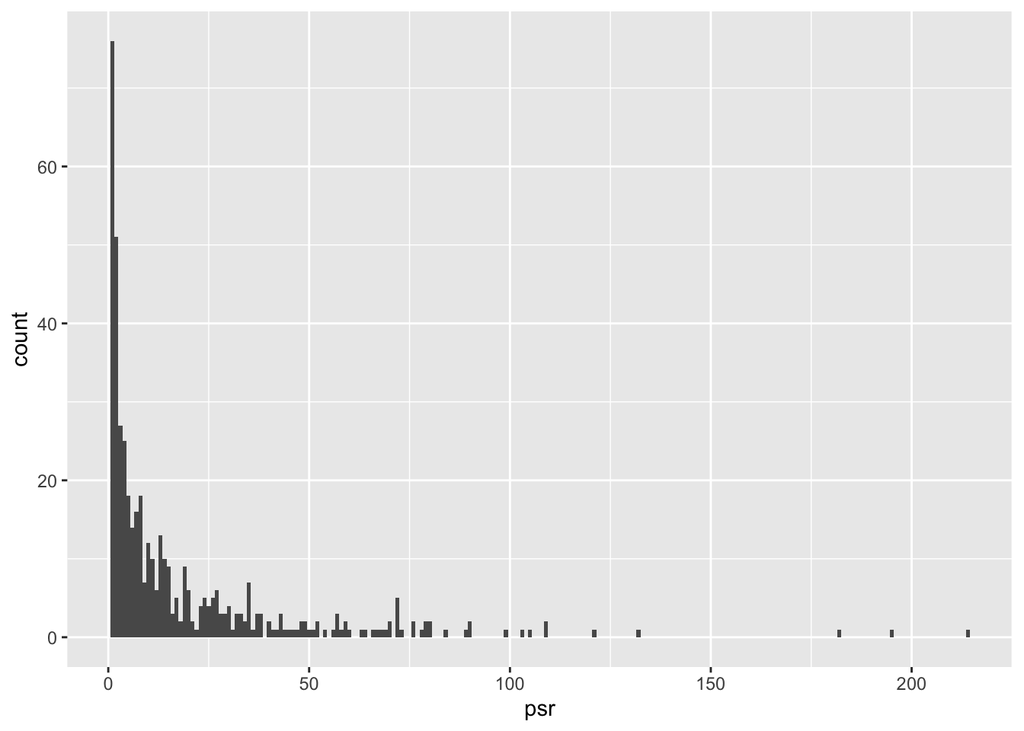

```r
ggplot(gmpd_panth, aes(x=psr)) + geom_histogram(binwidth = 1)
```

```r
library(reshape2)
```

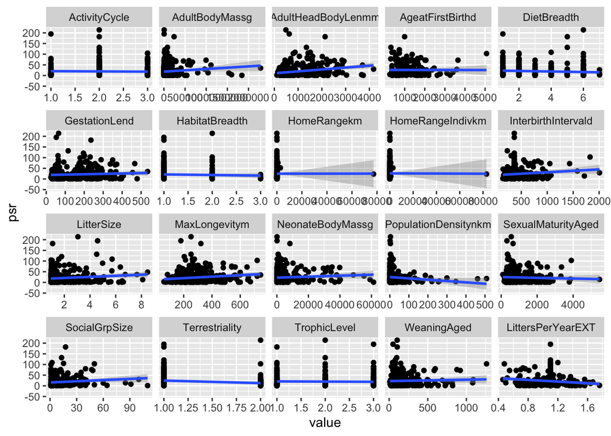

```r
gmpd_panth2 <- gmpd_panth %>% melt(., id.vars = "psr")
gmpd_panth2 %>% ggplot(.,aes(x=value,y=psr)) + geom_point() + geom_smooth(method="lm") + facet_wrap(~variable, scales = "free_x")
```

Multiple linear regression surely won’t work but why not GAMs??

```r
library(tree)
set.seed(07981)
train <- sample(1:nrow(gmpd_panth), nrow(gmpd_panth) / 2)
tree_gmpd <- tree(psr~., gmpd_panth, subset = train)
summary(tree_gmpd)
```

```
##
## Regression tree:
## tree(formula = psr ~ ., data = gmpd_panth, subset = train)
## Variables actually used in tree construction:
## [1] "AdultBodyMassg" "SocialGrpSize"
## Number of terminal nodes:  3
## Residual mean deviance:  309.6 = 4954 / 16
## Distribution of residuals:
##    Min. 1st Qu.  Median    Mean 3rd Qu.    Max.
## -30.400  -6.867  -2.333   0.000   6.133  45.600
```

cross-validation

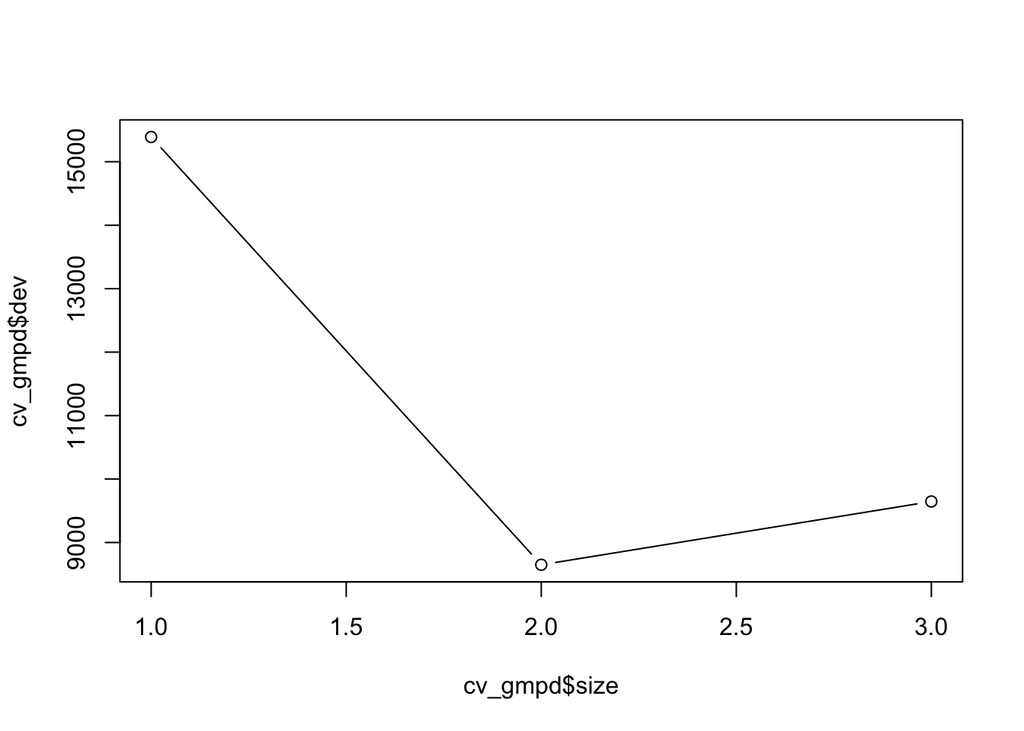

```r
cv_gmpd <- cv.tree(tree_gmpd)
plot (cv_gmpd$size , cv_gmpd$dev, type = "b")
```

prune

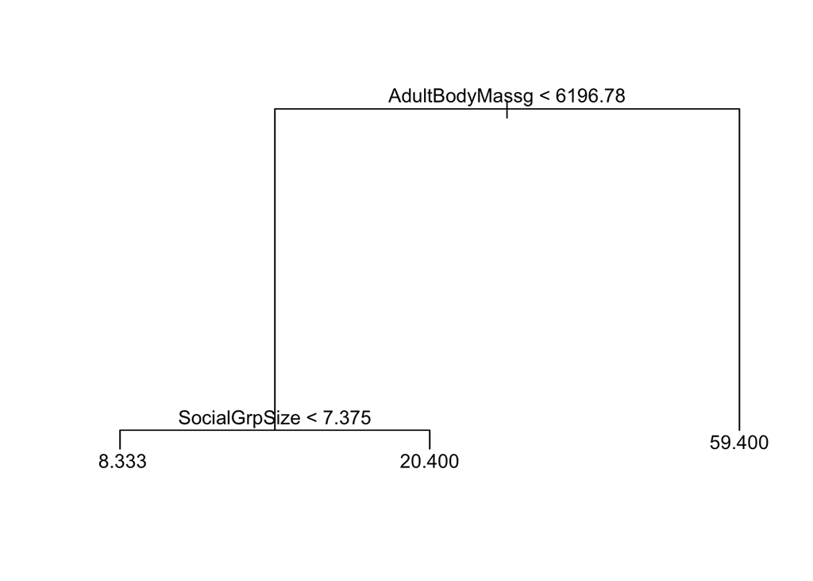

```r
prune_gmpd <- prune.tree(tree_gmpd, best = 3)
plot(prune_gmpd)
text(prune_gmpd)
```

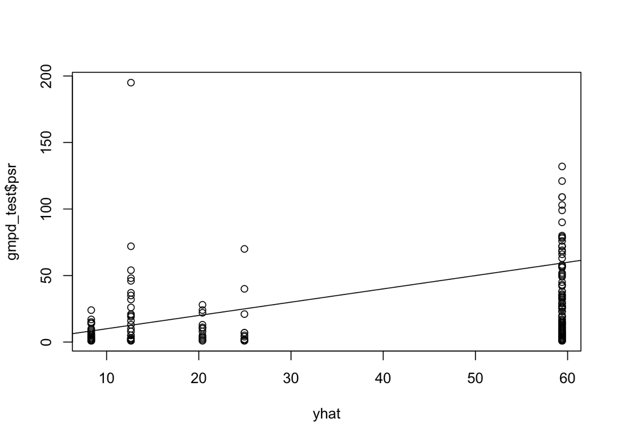

```r
yhat <- predict(tree_gmpd, newdata = gmpd_panth[-train , ])
gmpd_test <- gmpd_panth[-train , "psr"]
plot(yhat, gmpd_test$psr)
abline(0, 1)
```

```r
mean((yhat - gmpd_test$psr)^2)
```

```
## [1] 1343.406
```

test gbm

```r
library(gbm)
boost_gmpd <- gbm(psr~., data = gmpd_panth[train, ],
  distribution = "poisson", n.trees = 5000,
  interaction.depth = 4)
```

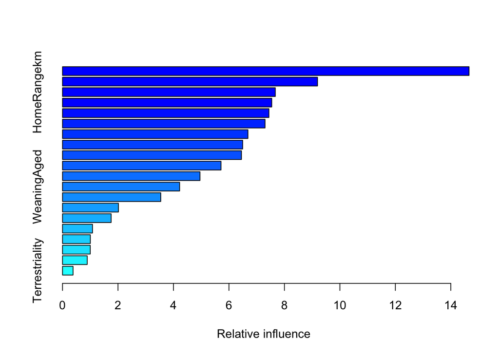

```
##                                       var    rel.inf
## AdultBodyMassg             AdultBodyMassg 14.6573584
## SexualMaturityAged     SexualMaturityAged  9.1941068
## HomeRangekm                   HomeRangekm  7.6726338
## NeonateBodyMassg         NeonateBodyMassg  7.5434390
## AdultHeadBodyLenmm     AdultHeadBodyLenmm  7.4422554
## MaxLongevitym               MaxLongevitym  7.3014221
## HomeRangeIndivkm         HomeRangeIndivkm  6.6842959
## LitterSize                     LitterSize  6.4955499
## PopulationDensitynkm PopulationDensitynkm  6.4511120
## GestationLend               GestationLend  5.7149395
## DietBreadth                   DietBreadth  4.9560519
## WeaningAged                   WeaningAged  4.2217010
## ActivityCycle               ActivityCycle  3.5416867
## InterbirthIntervald   InterbirthIntervald  2.0164357
## SocialGrpSize               SocialGrpSize  1.7535456
## LittersPerYearEXT       LittersPerYearEXT  1.0810180
## TrophicLevel                 TrophicLevel  1.0028974
## HabitatBreadth             HabitatBreadth  1.0002236
## AgeatFirstBirthd         AgeatFirstBirthd  0.8899128
## Terrestriality             Terrestriality  0.3794147
```

```r
summary(boost_gmpd)
```

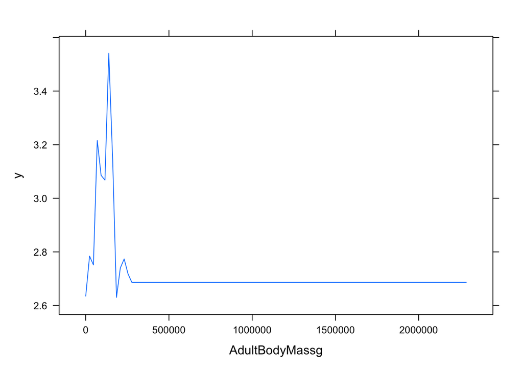

```r
plot.gbm(boost_gmpd, i.var=2)
```

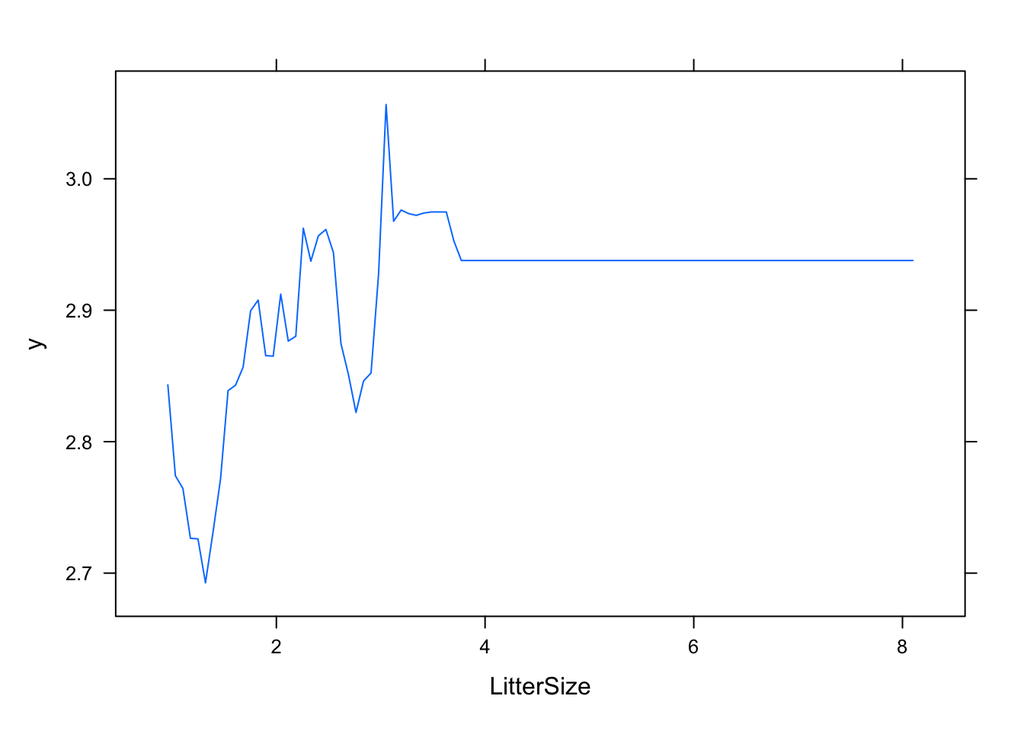

```r
plot.gbm(boost_gmpd, i.var=11)
```

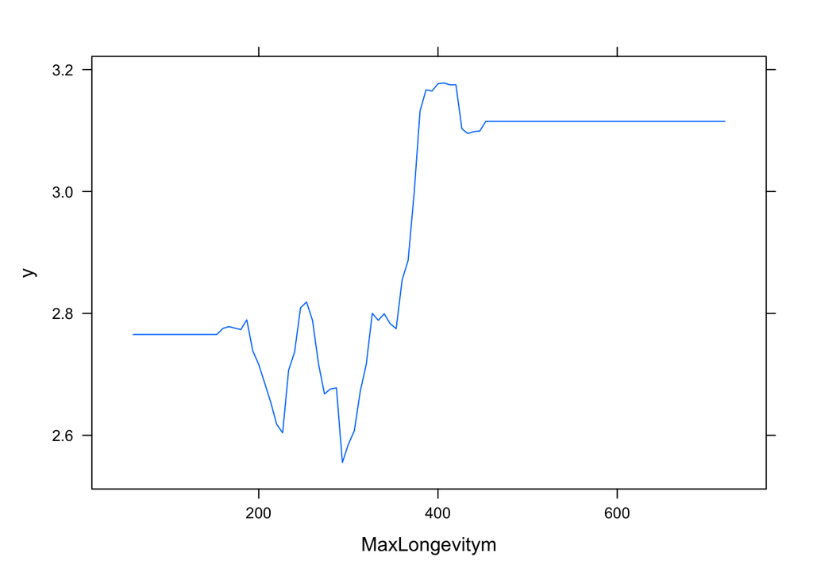

```r
plot.gbm(boost_gmpd, i.var=12)
```

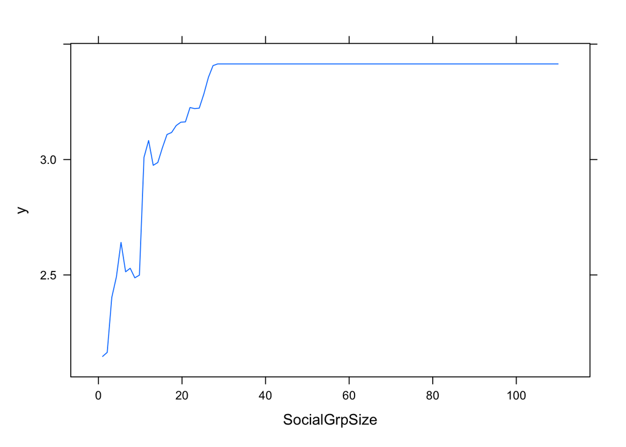

```r
plot.gbm(boost_gmpd, i.var=16)
```

```r
yhat_boost <- predict(boost_gmpd, newdata = gmpd_panth[-train, ], n.trees = 5000)
mean((yhat_boost-boost_gmpd$data$y)^2)
```

```
## [1] 871.4153
```

```r
sqrt(mean((yhat_boost-boost_gmpd$data$y)^2))
```

```
## [1] 29.51974
```

things to do:

- turn references column into reference count
- go through each variable and choose just the most important ones
- subset analysis by host or parasite type

```r
gmpd_VSR <- gmpd %>% filter(ParType == "Virus") %>% dplyr::select(HostCorrectedName,ParasiteCorrectedName) %>% distinct() %>%
  group_by(HostCorrectedName) %>% summarize(vsr=n())
gmpd_panth_v <- gmpd_VSR %>% inner_join(panth1, by="HostCorrectedName")
```

Let’s deal with all the -999 and the references column and the numbers and weird stuff in the column names!!

```r
gmpd_panth_v <- na_if(gmpd_panth_v, -999.00)
gmpd_panth_v %<>% dplyr::select(vsr, 8, 9, 11, 13, 16, 18:23, 25, 26, 28, 30, 31, 33, 34, 35, 40)
names(gmpd_panth_v) <- gsub("[[:digit:]]", "", names(gmpd_panth_v))
names(gmpd_panth_v) <- gsub("-_", "", names(gmpd_panth_v))
names(gmpd_panth_v) <- gsub("_", "", names(gmpd_panth_v))
names(gmpd_panth_v) <- gsub(" ", "", names(gmpd_panth_v))
names(gmpd_panth_v) <- gsub("/", "", names(gmpd_panth_v))
```

```r
train <- sample(1:nrow(gmpd_panth_v), nrow(gmpd_panth_v) / 2)

boost_gmpd_v <- gbm(vsr~., data = gmpd_panth_v[train, ],
  distribution = "poisson", n.trees = 5000,
  interaction.depth = 4)
```

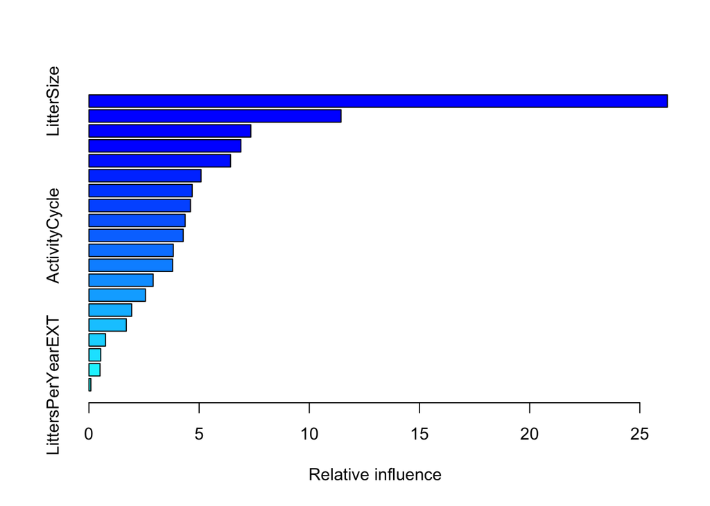

```
##                                       var     rel.inf
## LitterSize                     LitterSize 26.25049425
## AdultBodyMassg             AdultBodyMassg 11.44026752
## MaxLongevitym               MaxLongevitym  7.34596768
## HomeRangeIndivkm         HomeRangeIndivkm  6.89747502
## GestationLend               GestationLend  6.42602544
## AgeatFirstBirthd         AgeatFirstBirthd  5.08745412
## PopulationDensitynkm PopulationDensitynkm  4.68549077
## WeaningAged                   WeaningAged  4.60692268
## HomeRangekm                   HomeRangekm  4.36632199
## ActivityCycle               ActivityCycle  4.27731914
## InterbirthIntervald   InterbirthIntervald  3.82643587
## AdultHeadBodyLenmm     AdultHeadBodyLenmm  3.79670584
## SexualMaturityAged     SexualMaturityAged  2.91309901
## SocialGrpSize               SocialGrpSize  2.56516970
## NeonateBodyMassg         NeonateBodyMassg  1.94044784
## DietBreadth                   DietBreadth  1.69633624
## HabitatBreadth             HabitatBreadth  0.75280106
## Terrestriality             Terrestriality  0.53446943
## TrophicLevel                 TrophicLevel  0.50408245
## LittersPerYearEXT       LittersPerYearEXT  0.08671395
```

```r
summary(boost_gmpd_v)
```

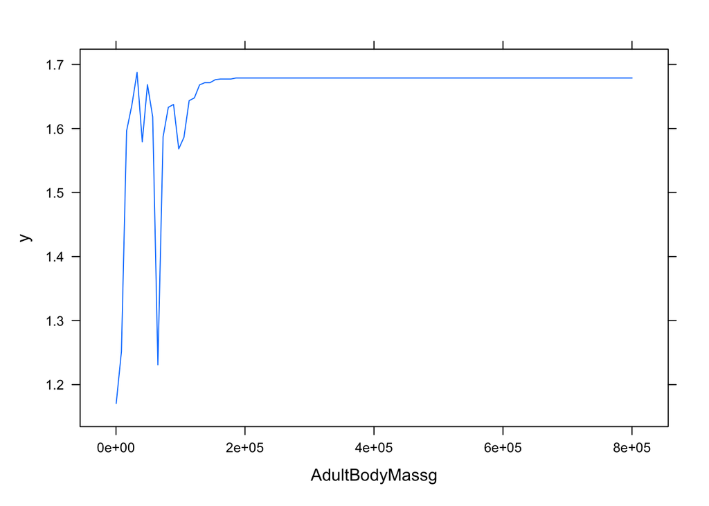

```r
plot.gbm(boost_gmpd_v, i.var=2)
```

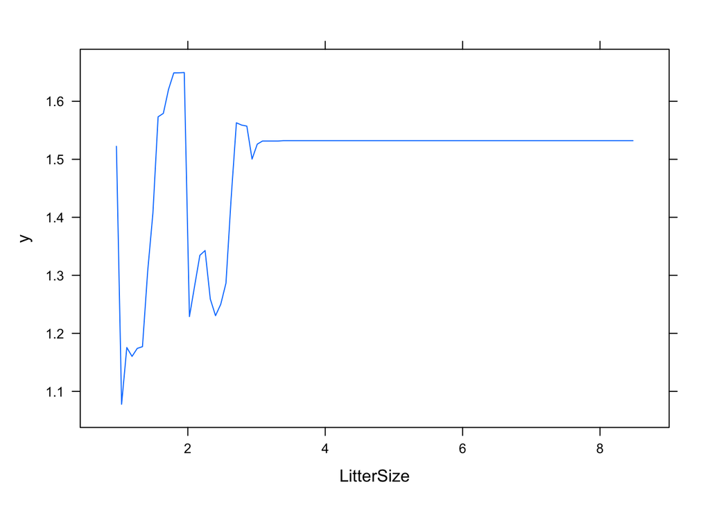

```r
plot.gbm(boost_gmpd_v, i.var=11)
```

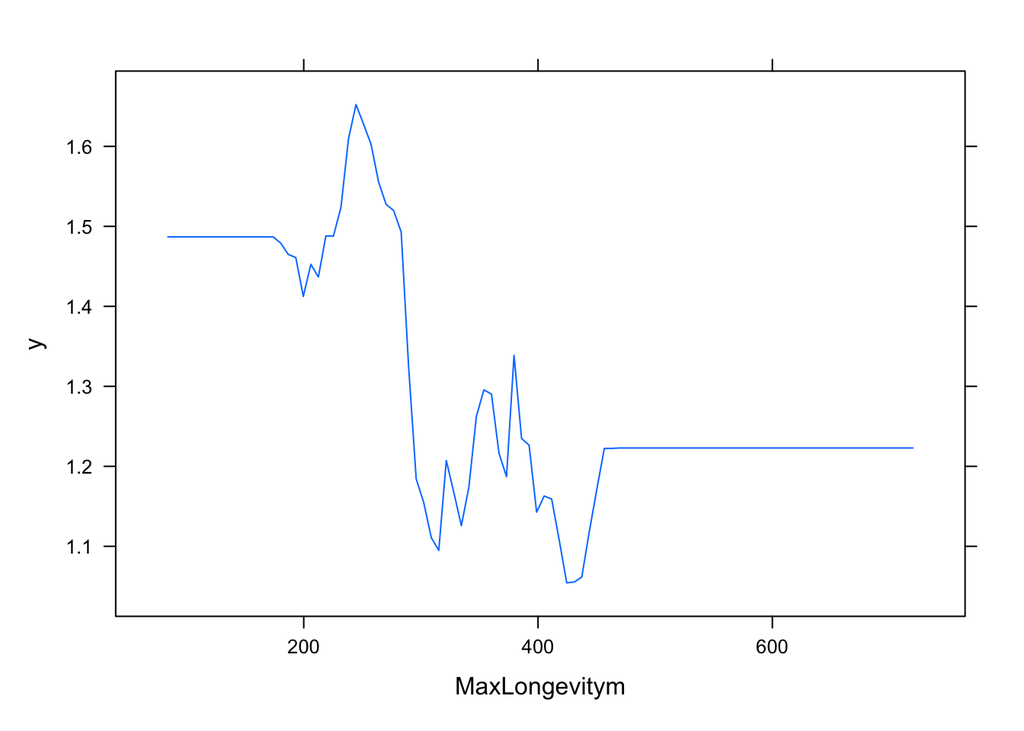

```r
plot.gbm(boost_gmpd_v, i.var=12)
```

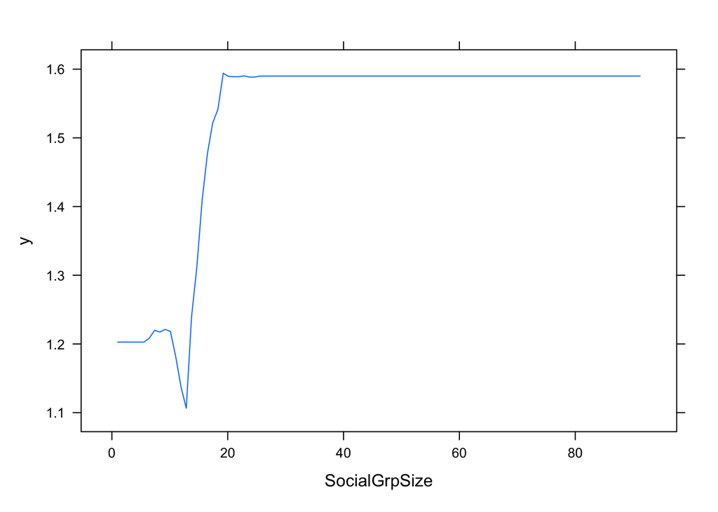

```r
plot.gbm(boost_gmpd_v, i.var=16)
```

```r
yhat_boost_v <- predict(boost_gmpd_v, newdata = gmpd_panth_v[-train, ], n.trees = 5000)
mean((yhat_boost_v-boost_gmpd_v$data$y)^2)
```

```
## [1] 22.84287
```

```r
sqrt(mean((yhat_boost_v-boost_gmpd_v$data$y)^2))
```

```
## [1] 4.779421
```

Now again with helminths!

```r
gmpd_HSR <- gmpd %>% filter(ParType == "Helminth") %>% dplyr::select(HostCorrectedName,ParasiteCorrectedName) %>% distinct() %>%
  group_by(HostCorrectedName) %>% summarize(hsr=n())
gmpd_panth_h <- gmpd_HSR %>% inner_join(panth1, by="HostCorrectedName")
```

Let’s deal with all the -999 and the references column and the numbers and weird stuff in the column names!!

```r
gmpd_panth_h <- na_if(gmpd_panth_h, -999.00)
gmpd_panth_h %<>% dplyr::select(hsr, 8, 9, 11, 13, 16, 18:23, 25, 26, 28, 30, 31, 33, 34, 35, 40)
names(gmpd_panth_h) <- gsub("[[:digit:]]", "", names(gmpd_panth_h))
names(gmpd_panth_h) <- gsub("-_", "", names(gmpd_panth_h))
names(gmpd_panth_h) <- gsub("_", "", names(gmpd_panth_h))
names(gmpd_panth_h) <- gsub(" ", "", names(gmpd_panth_h))
names(gmpd_panth_h) <- gsub("/", "", names(gmpd_panth_h))
```

```r
train <- sample(1:nrow(gmpd_panth_h), nrow(gmpd_panth_h) / 2)
boost_gmpd_h <- gbm(hsr~., data = gmpd_panth_h[train, ],
  distribution = "poisson", n.trees = 5000,
  interaction.depth = 4)
```

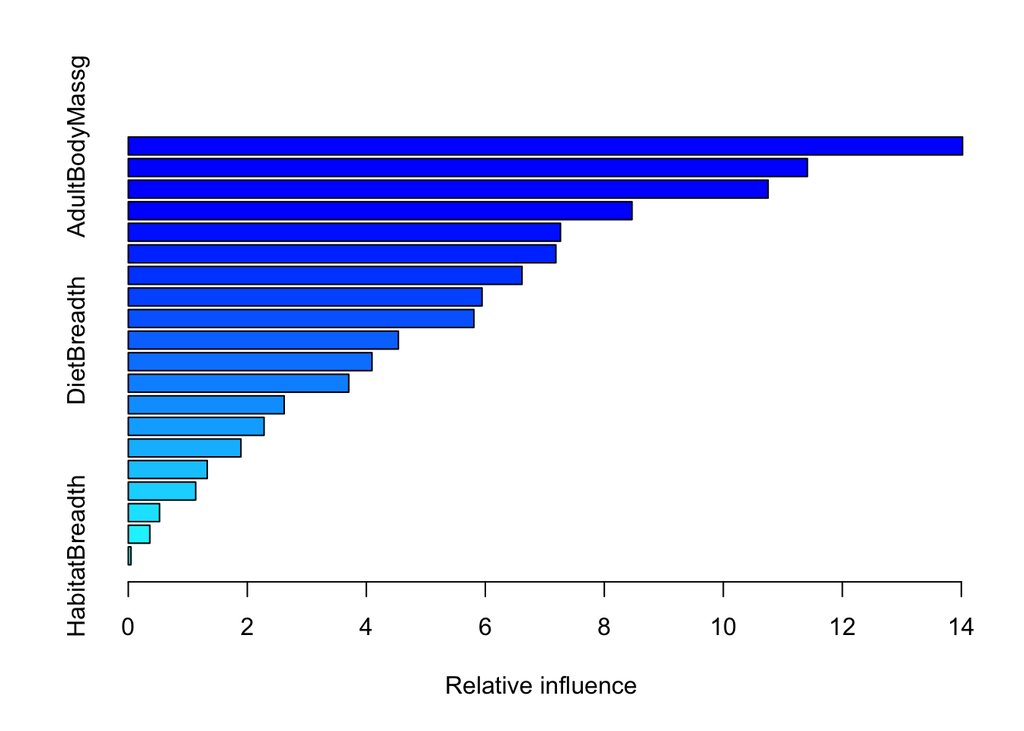

```
##                                       var     rel.inf
## AdultBodyMassg             AdultBodyMassg 14.02070204
## SexualMaturityAged     SexualMaturityAged 11.41277372
## PopulationDensitynkm PopulationDensitynkm 10.75309169
## LitterSize                     LitterSize  8.46601768
## HomeRangekm                   HomeRangekm  7.26364869
## AdultHeadBodyLenmm     AdultHeadBodyLenmm  7.18639023
## GestationLend               GestationLend  6.61728561
## MaxLongevitym               MaxLongevitym  5.94565479
## WeaningAged                   WeaningAged  5.80787129
## DietBreadth                   DietBreadth  4.53878751
## HomeRangeIndivkm         HomeRangeIndivkm  4.09579611
## NeonateBodyMassg         NeonateBodyMassg  3.70530886
## ActivityCycle               ActivityCycle  2.62041625
## AgeatFirstBirthd         AgeatFirstBirthd  2.28176638
## TrophicLevel                 TrophicLevel  1.89300090
## SocialGrpSize               SocialGrpSize  1.32716530
## InterbirthIntervald   InterbirthIntervald  1.13268562
## LittersPerYearEXT       LittersPerYearEXT  0.52547844
## Terrestriality             Terrestriality  0.36204697
## HabitatBreadth             HabitatBreadth  0.04411192
```

```r
summary(boost_gmpd_h)
```

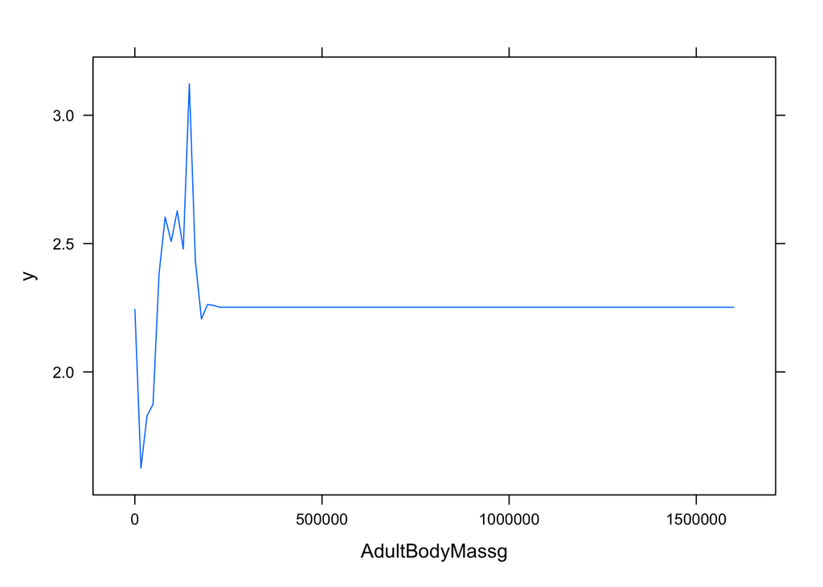

```r
plot.gbm(boost_gmpd_h, i.var=2)
```

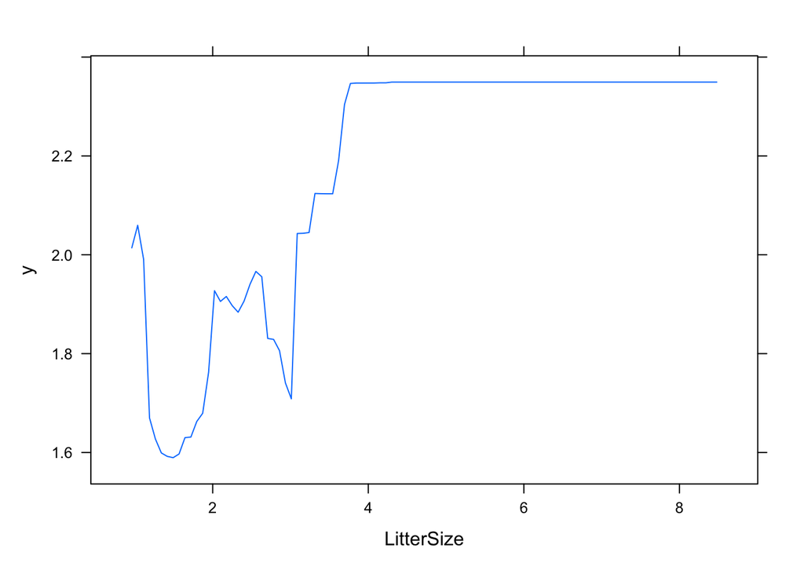

```r
plot.gbm(boost_gmpd_h, i.var=11)
```

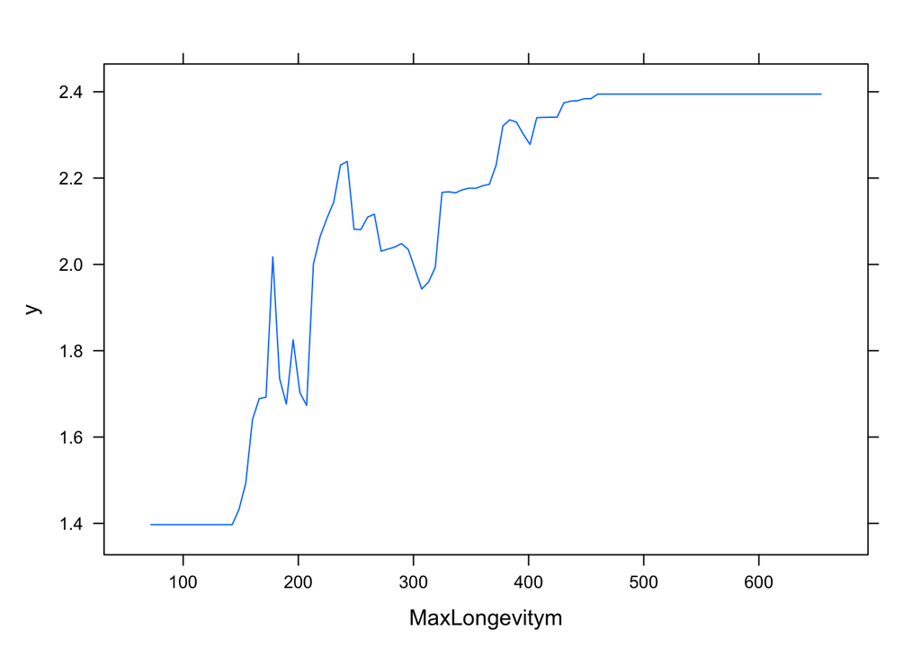

```r
plot.gbm(boost_gmpd_h, i.var=12)
```

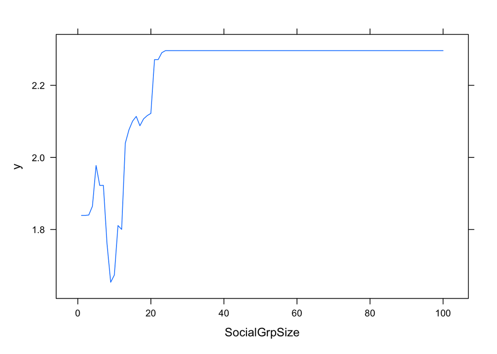

```r
plot.gbm(boost_gmpd_h, i.var=16)
```

```r
yhat_boost_h <- predict(boost_gmpd_h, newdata = gmpd_panth_h[-train, ], n.trees = 5000)
mean((yhat_boost_h-boost_gmpd_h$data$y)^2)
```

```
## [1] 285.9112
```

```r
sqrt(mean((yhat_boost_h-boost_gmpd_h$data$y)^2))
```

```
## [1] 16.90891
```

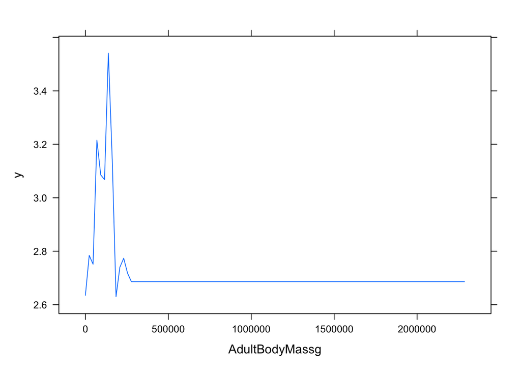

```r
plot.gbm(boost_gmpd, i.var=2)
```

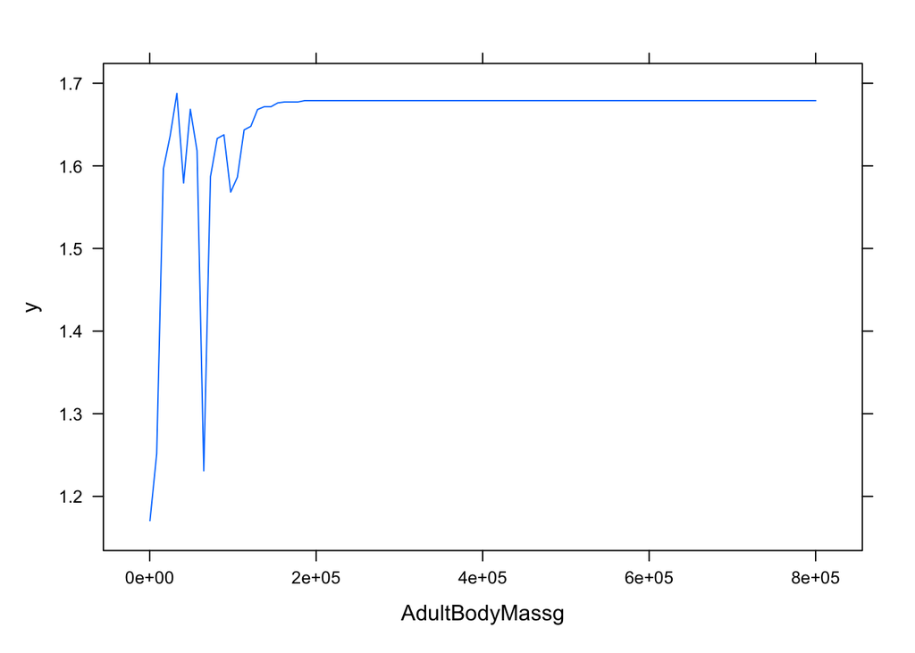

```r
plot.gbm(boost_gmpd_v, i.var=2)
```

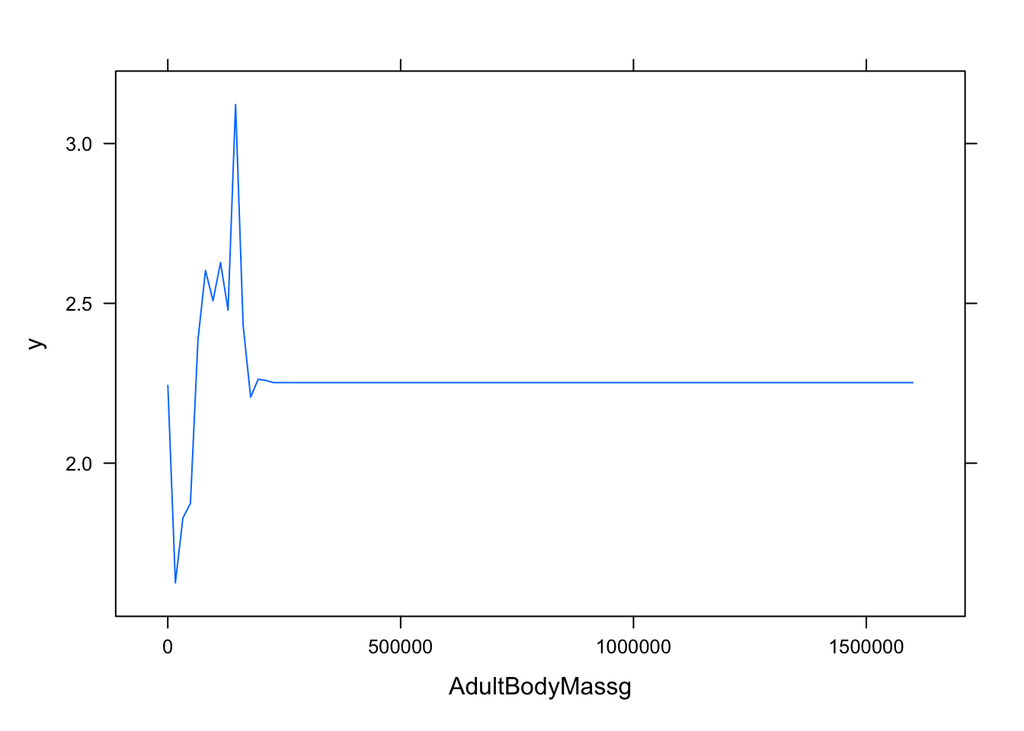

```r
plot.gbm(boost_gmpd_h, i.var=2)
```

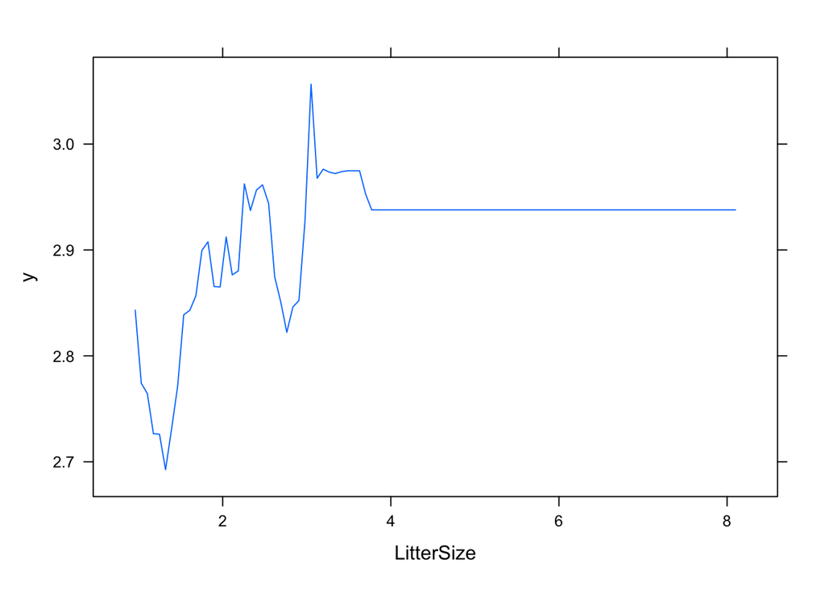

```r
plot.gbm(boost_gmpd, i.var=11)
```

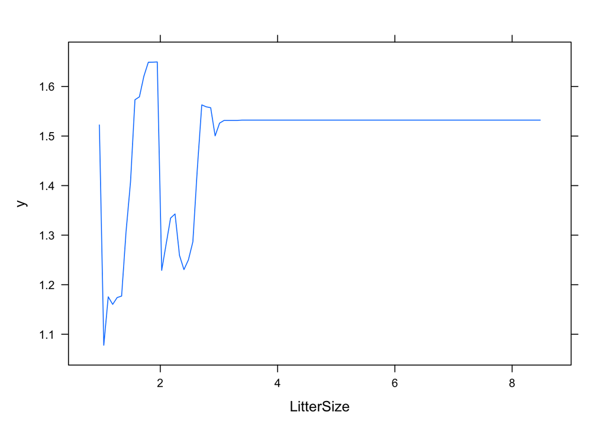

```r
plot.gbm(boost_gmpd_v, i.var=11)
```

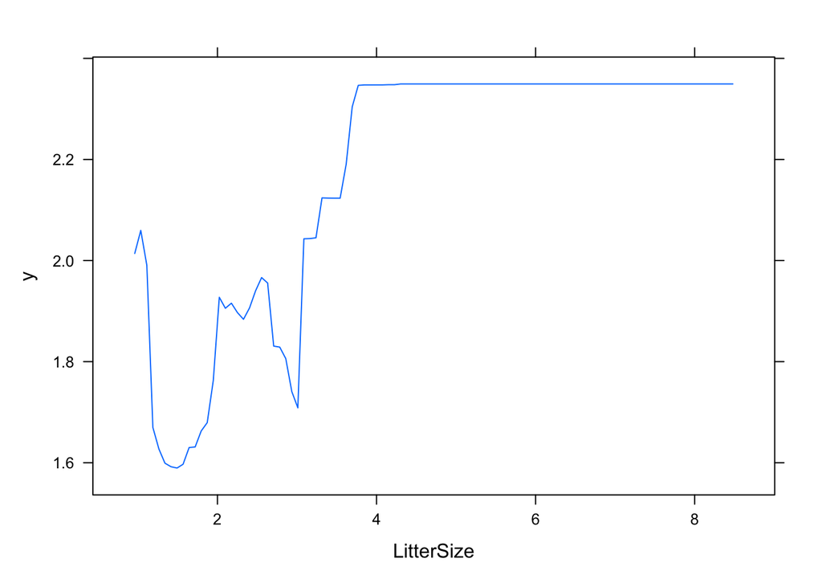

```r
plot.gbm(boost_gmpd_h, i.var=11)
```

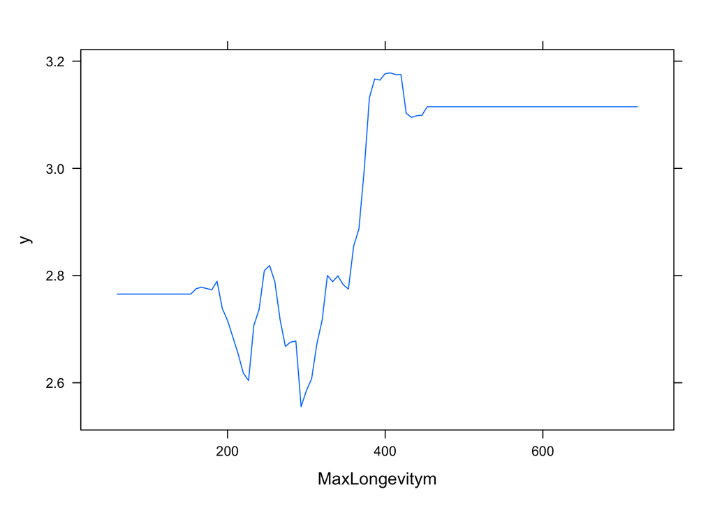

```r
plot.gbm(boost_gmpd, i.var=12)
```

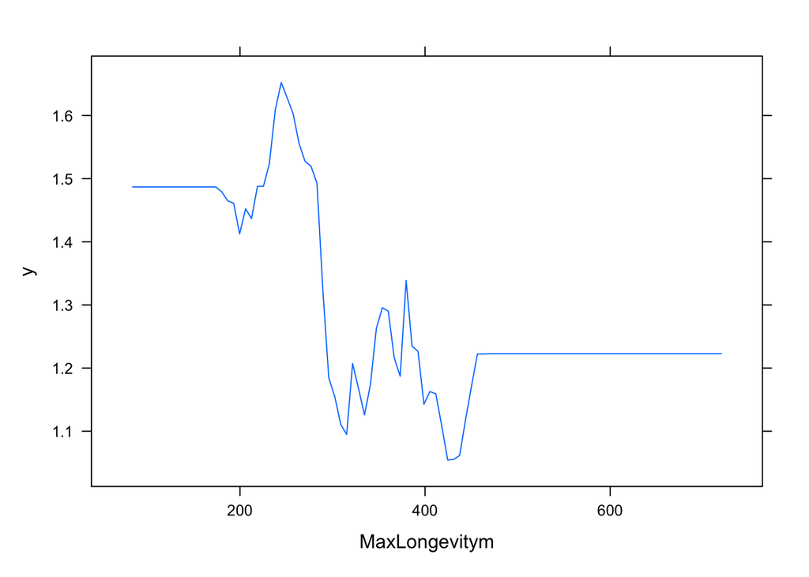

```r
plot.gbm(boost_gmpd_v, i.var=12)
```

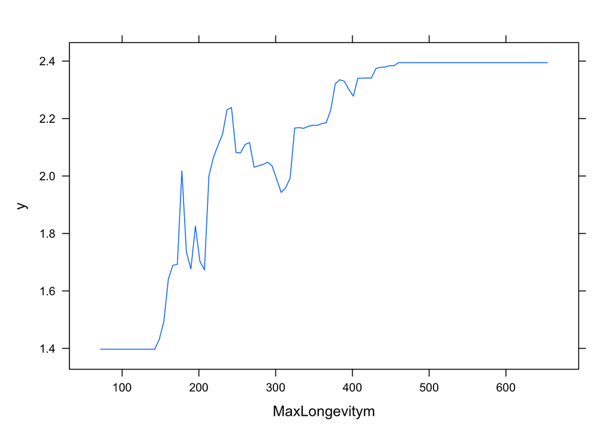

```r
plot.gbm(boost_gmpd_h, i.var=12)
```